# Oklahoma Purchase Credit Card Transactions Project

The Office of Management and Enterprise Services in the State of Oklahoma has made its purchase credit card transactions available. This dataset contains information on purchases made through the purchase card programs administered by the state and higher education institutions.

## Section 1 Data Preparation

```python
import numpy as np
import pandas as pd
import seaborn as sns
import matplotlib.pyplot as plt
```

```python
df = pd.read_csv('purchase_credit_card.csv')
df
```

|  | Year-Month | Agency Number | Agency Name | Cardholder Last Name | Cardholder First Initial | Description | Amount | Vendor | Transaction Date | Posted Date | Merchant Category Code (MCC) |
| --- | --- | --- | --- | --- | --- | --- | --- | --- | --- | --- | --- |
| 0 | 201307 | 1000 | OKLAHOMA STATE UNIVERSITY | Mason | C | GENERAL PURCHASE | 890.00 | NACAS | 7/30/13 0:00 | 7/31/13 0:00 | CHARITABLE AND SOCIAL SERVICE ORGANIZATIONS |
| 1 | 201307 | 1000 | OKLAHOMA STATE UNIVERSITY | Mason | C | ROOM CHARGES | 368.96 | SHERATON HOTEL | 7/30/13 0:00 | 7/31/13 0:00 | SHERATON |
| 2 | 201307 | 1000 | OKLAHOMA STATE UNIVERSITY | Massey | J | GENERAL PURCHASE | 165.82 | SEARS.COM 9300 | 7/29/13 0:00 | 7/31/13 0:00 | DIRCT MARKETING/DIRCT MARKETERS--NOT ELSEWHERE... |
| 3 | 201307 | 1000 | OKLAHOMA STATE UNIVERSITY | Massey | T | GENERAL PURCHASE | 96.39 | WAL-MART #0137 | 7/30/13 0:00 | 7/31/13 0:00 | GROCERY STORES,AND SUPERMARKETS |
| 4 | 201307 | 1000 | OKLAHOMA STATE UNIVERSITY | Mauro-Herrera | M | HAMMERMILL COPY PLUS COPY EA | 125.96 | STAPLES DIRECT | 7/30/13 0:00 | 7/31/13 0:00 | STATIONERY, OFFICE SUPPLIES, PRINTING AND WRIT... |
| ... | ... | ... | ... | ... | ... | ... | ... | ... | ... | ... | ... |
| 442453 | 201406 | 98000 | GRAND RIVER DAM AUTH. | Cardholder | e | GENERAL PURCHASE | 992.00 | TOTAL VALVE SYSTEMS | 6/20/14 0:00 | 6/23/14 0:00 | HARDWARE EQUIPMENT AND SUPPLIES |
| 442454 | 201406 | 98000 | GRAND RIVER DAM AUTH. | Cardholder | e | GENERAL PURCHASE | 2415.00 | PRYOR WASTE & RECYCLING L | 6/20/14 0:00 | 6/23/14 0:00 | UTILITIES - ELECTRIC,GAS,WATER,SANITARY |
| 442455 | 201406 | 98000 | GRAND RIVER DAM AUTH. | Cardholder | e | GENERAL PURCHASE | 177.50 | ACCURATE ENVIROMENTAL LAB | 6/20/14 0:00 | 6/23/14 0:00 | BUSINESS SERVICES NOT ELSEWHERE CLASSIFIED |
| 442456 | 201406 | 98000 | GRAND RIVER DAM AUTH. | Cardholder | e | GENERAL PURCHASE | 32457.00 | RED BUD SERVICE INC | 6/19/14 0:00 | 6/23/14 0:00 | PROFESSIONAL SERVICES NOT ELSEWHERE CLASSIFIED |
| 442457 | 201406 | 98000 | GRAND RIVER DAM AUTH. | Cardholder | e | GENERAL PURCHASE | 4714.07 | WARRENCAT CREDIT DEPT | 6/20/14 0:00 | 6/23/14 0:00 | MISCELLANEOUS AND SPECIALTY RETAIL STORES |

442458 rows × 11 columns

```python
# change column names
df.columns = ['Year_Month', 'Agency_Number', 'Agency_Name', 'Cardholder_Last_Name',
      'Cardholder_First_Initial', 'Description', 'Amount', 'Vendor', 'Transaction_Date',
      'Posted_Date', 'Merchant_Category']
```

### 1.1 Create date fields

```python
#Creating separate Year and Month columns for future feature engineering
# Converting Transaction_Date and Posted_date from Python Object data type to datetime
df['Transaction_Date']=pd.to_datetime(df['Transaction_Date'])
df['Posted_Date']=pd.to_datetime(df['Posted_Date'])

df['Year_Month'].dtype
df['Year_Month']=pd.to_datetime(df['Year_Month'], format='%Y%m')
df['Year'] = df['Year_Month'].dt.year
df['Month'] = df['Year_Month'].dt.month
#Creating 'Week_Number' from 'Transaction_Date'
df['Week_Number'] = df['Transaction_Date'].dt.isocalendar().week

#Creating 'Day_of_Week' from 'Transaction_Date'
dayOfWeek={0:'Monday', 1:'Tuesday', 2:'Wednesday', 3:'Thursday', 4:'Friday', 5:'Saturday', 6:'Sunday'}
df['Day_of_Week'] = df['Transaction_Date'].dt.dayofweek.map(dayOfWeek)

df['Day_of_Week'].value_counts()
```

```
Wednesday    89644
Thursday     87537
Tuesday      86919
Friday       79917
Monday       61809
Saturday     26307
Sunday       10325
Name: Day_of_Week, dtype: int64
```

## Section 2 Initial observations

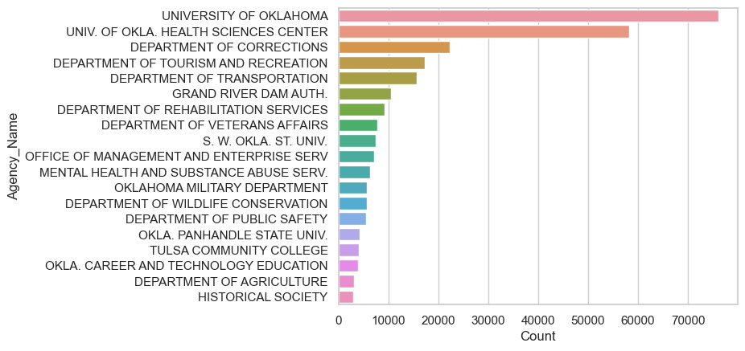

```python
import numpy as np
import plotly
import pandas as pd
import plotly.express as px

# Summarize the count statistics by agency_name in df_count
df_count = df['Agency_Name'].value_counts()
df_count = pd.DataFrame(df_count).reset_index()
df_count.columns = ['Agency_Name','Count']

fig = px.bar(df_count, x='Agency_Name', y='Count', color = 'Agency_Name', width=1000, height=400)
import seaborn as sns
sns.set_theme(style="whitegrid")
sns.barplot(y="Agency_Name", x="Count", data=df_count[1:20])
```

## Section 3 Create Features

### 3.1 Feature 1: The Ratio to the Median Amount

```python
# create average spending group by agency and merchant category
stat_by_agency = df.groupby(['Agency_Name', 'Merchant_Category'])['Amount'].median()
stat_by_agency = pd.DataFrame(stat_by_agency)
stat_by_agency.columns = ['Median_amount']
```

```python
# add the new feature average spending to the dataset
df1 = pd.merge(df, stat_by_agency, how='left', on=['Agency_Name', 'Merchant_Category'])
# Feature 1: ratio of amount spending and avergae spending by merchant category
df1['agency_merchant_median_ratio_amount'] = np.where(df1['Median_amount']==0,0, df1['Amount'] / df1['Median_amount'])
df1['agency_merchant_median_ratio_amount'].describe()
```

```
count    442458.000000
mean          4.952685
std        1078.581350
min       -1003.176471
25%           0.466090
50%           1.000000
75%           2.121102
max      528116.052705
Name: agency_merchant_median_ratio_amount, dtype: float64
```

```python
# cut by percentile for plotting
var = 'agency_merchant_median_ratio_amount'
binned_var = var + '_D'
percentile = [0,0.01,0.05,0.2,0.5,0.8,0.95,0.99,1]
df1[binned_var] = pd.qcut( df1[var],percentile)
df1['agency_merchant_median_ratio_amount']
```

```
0          3.560000
1          1.407761
2          0.966824
3          2.967216
4          1.143895
            ...
442453     1.948537
442454     4.875242
442455     0.478089
442456    54.566087
442457    14.285061
Name: agency_merchant_median_ratio_amount, Length: 442458, dtype: float64
```

[output not shown]

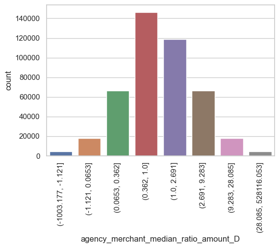

```python
import matplotlib.pyplot as plt
plt.figure(figsize=(6,4))
g = sns.countplot(x="agency_merchant_median_ratio_amount_D", data=df1)
g.set_xticklabels(g.get_xticklabels(), rotation=90)
```

### 3.2 Feature 2: The Ratio to the Average Amount

```python
# create average spending group by agency and merchant category
stat_by_agency = df.groupby(['Agency_Name', 'Merchant_Category'])['Amount'].mean()
stat_by_agency = pd.DataFrame(stat_by_agency)
stat_by_agency.columns = ['AVG_amount']
stat_by_agency
```

| Agency_Name | Merchant_Category | AVG_amount |
| --- | --- | --- |
| ARDMORE HIGHER EDUCATION CENTER | BUSINESS SERVICES NOT ELSEWHERE CLASSIFIED | 115.120000 |
|  | CATALOG MERCHANTS | -53.344286 |
|  | COMPUTER NETWORK/INFORMATION SERVICES | 18.340000 |
|  | DRUG STORES AND PHARMACIES | 153.450000 |
|  | GROCERY STORES,AND SUPERMARKETS | 74.525455 |
| ... | ... | ... |
| `DEPARTMENT OF EDUCATION | TELECOMMUNICATION SERVICES | 118.054000 |
|  | TRAVEL AGENCIES | 24.253731 |
|  | TROPICANA RESORT AND CASINO | 481.600000 |
|  | UNITED AIRLINES | 310.547368 |
|  | WYNDHAM HOTELS | 93.282857 |

8427 rows × 1 columns

```python
# add the new feature average spending to the dataset
df2 = pd.merge(df, stat_by_agency, how='left', on=['Agency_Name', 'Merchant_Category'])
# Feature 1: ratio of amount spending and avergae spending by merchant category
df2['agency_merchant_avg_ratio_amount'] = np.where(df2['AVG_amount']==0,0, df2['Amount'] / df2['AVG_amount'])
df2['agency_merchant_avg_ratio_amount'].describe()
```

```
count    442458.000000
mean          0.999724
std           7.225363
min       -2735.680000
25%           0.177145
50%           0.515301
75%           1.102916
max        2735.680000
Name: agency_merchant_avg_ratio_amount, dtype: float64
```

```python
# cut by percentile for plotting
var = 'agency_merchant_avg_ratio_amount'
binned_var = var + '_D'
percentile = [0,0.01,0.05,0.2,0.5,0.8,0.95,0.99,1]
df2[binned_var] = pd.qcut( df2[var],percentile)
df2[['agency_merchant_avg_ratio_amount_D']]
```

|  | agency_merchant_avg_ratio_amount_D |
| --- | --- |
| 0 | (1.298, 3.515] |
| 1 | (0.515, 1.298] |
| 2 | (0.133, 0.515] |
| 3 | (1.298, 3.515] |
| 4 | (0.133, 0.515] |
| ... | ... |
| 442453 | (0.515, 1.298] |
| 442454 | (0.133, 0.515] |
| 442455 | (0.0212, 0.133] |
| 442456 | (8.71, 2735.68] |
| 442457 | (1.298, 3.515] |

442458 rows × 1 columns

[output not shown]

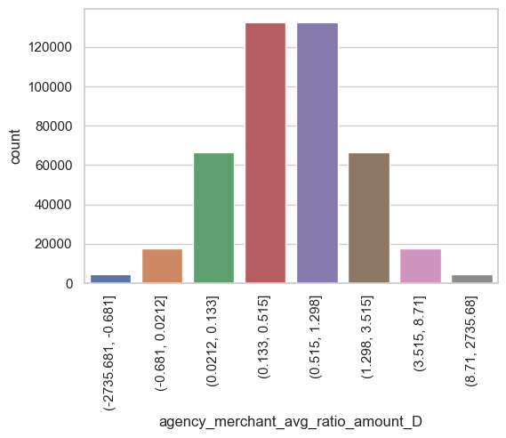

```python
import matplotlib.pyplot as plt
plt.figure(figsize=(6,4))
g = sns.countplot(x="agency_merchant_avg_ratio_amount_D", data=df2)
g.set_xticklabels(g.get_xticklabels(), rotation=90)
```

### 3.3 Feature 3: Log Transformation of Transaction Amount

##### The log transformation of transaction amount is applied to reduced the skewness. Transactions with very large or very small amounts will be more evident in the log transformated data, helping to detect the usual high or low value that could indicate as anomalies.

```python
df['log_amount'] = np.log(df['Amount'] + 1)
df.head()
```

|  | Year_Month | Agency_Number | Agency_Name | Cardholder_Last_Name | Cardholder_First_Initial | Description | Amount | Vendor | Transaction_Date | Posted_Date | Merchant_Category | Year | Month | Week_Number | Day_of_Week | log_amount |
| --- | --- | --- | --- | --- | --- | --- | --- | --- | --- | --- | --- | --- | --- | --- | --- | --- |
| 0 | 2013-07-01 | 1000 | OKLAHOMA STATE UNIVERSITY | Mason | C | GENERAL PURCHASE | 890.00 | NACAS | 2013-07-30 | 2013-07-31 | CHARITABLE AND SOCIAL SERVICE ORGANIZATIONS | 2013 | 7 | 31 | Tuesday | 6.792344 |
| 1 | 2013-07-01 | 1000 | OKLAHOMA STATE UNIVERSITY | Mason | C | ROOM CHARGES | 368.96 | SHERATON HOTEL | 2013-07-30 | 2013-07-31 | SHERATON | 2013 | 7 | 31 | Tuesday | 5.913395 |
| 2 | 2013-07-01 | 1000 | OKLAHOMA STATE UNIVERSITY | Massey | J | GENERAL PURCHASE | 165.82 | SEARS.COM 9300 | 2013-07-29 | 2013-07-31 | DIRCT MARKETING/DIRCT MARKETERS--NOT ELSEWHERE... | 2013 | 7 | 31 | Monday | 5.116915 |
| 3 | 2013-07-01 | 1000 | OKLAHOMA STATE UNIVERSITY | Massey | T | GENERAL PURCHASE | 96.39 | WAL-MART #0137 | 2013-07-30 | 2013-07-31 | GROCERY STORES,AND SUPERMARKETS | 2013 | 7 | 31 | Tuesday | 4.578724 |
| 4 | 2013-07-01 | 1000 | OKLAHOMA STATE UNIVERSITY | Mauro-Herrera | M | HAMMERMILL COPY PLUS COPY EA | 125.96 | STAPLES DIRECT | 2013-07-30 | 2013-07-31 | STATIONERY, OFFICE SUPPLIES, PRINTING AND WRIT... | 2013 | 7 | 31 | Tuesday | 4.843872 |

### 3.4 Feature 4: Frequency of day of week

##### This feature calculates the number of transactions made by a cardholder on specific days of the week, like Monday, Tuesday, etc. An unusual increase or decrease in the number of transactions for certain days might indicate anomalies. Most people have regular spending habits based on the day of the week, like spending on groceries every certain day in a week. Unusually high activity on certain days where the cardholder has little or no transactions might refer to suspicious behavior.

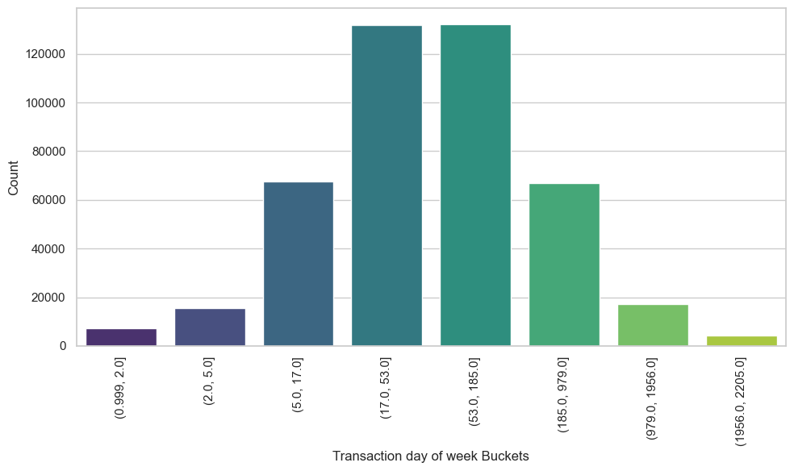

```python
df['day_of_week'] = df['Transaction_Date'].dt.day_name()
percentiles = [0, 0.01, 0.05, 0.2, 0.5, 0.8, 0.95, 0.99, 1]
df['day_of_week_frequency'] = df.groupby(['Cardholder_Last_Name', 'day_of_week'])['Amount'].transform('count')
df['day_of_week_freq_bucket'] = pd.qcut(df['day_of_week_frequency'], q=percentiles, duplicates='drop')
df[['day_of_week', 'day_of_week_frequency', 'day_of_week_freq_bucket']].head()


# Plot the distribution of time_diff_bucket
plt.figure(figsize=(10, 6))
sns.countplot(x='day_of_week_freq_bucket', data=df, palette='viridis')
plt.xticks(rotation=90)
plt.xlabel('Transaction day of week Buckets')
plt.ylabel('Count')
plt.tight_layout()
plt.show()
```

### 3.5 Feature 5: Z-score for Transaction Amount

##### Z-score helps to normalize the transaction. It is a way to see how far a particular value is from the mean value in a dataset and how many standard deviations values are away from the mean. The further a Z-score is from 0, whether positive or negative, the more extreme that the value is. For example, a value has a very high or low Z-score, it might be an outlier

```python
df['amount_zscore'] = (df['Amount'] - df['Amount'].mean()) / df['Amount'].std()
```

### 3.6 Feature 6: Frequency of Transaction per Day

```python
#transactions per day for each cardholder
df['daily_transaction_count'] = df.groupby(['Cardholder_Last_Name', 'Cardholder_First_Initial', 'Transaction_Date'])['Amount'].transform('count')
```

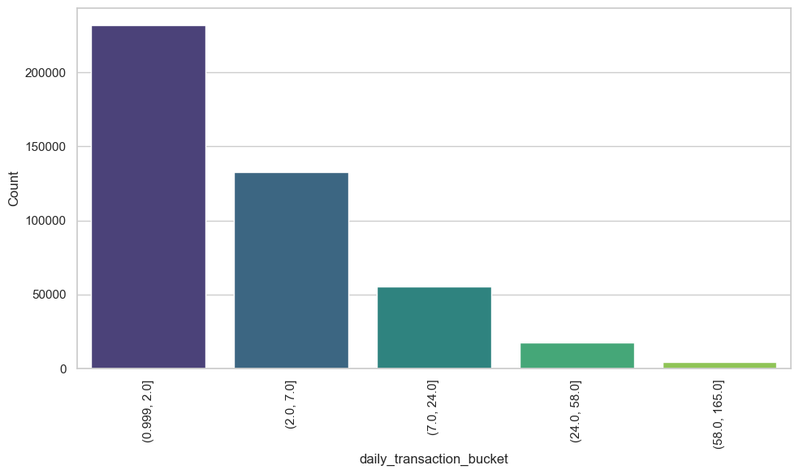

```python
df['daily_transaction_bucket'] = pd.qcut(df['daily_transaction_count'], q=percentiles, duplicates='drop')
df[['daily_transaction_count', 'daily_transaction_bucket']].head()
plt.figure(figsize=(10, 6))
sns.countplot(x='daily_transaction_bucket', data=df, palette='viridis')
plt.xticks(rotation=90)
plt.xlabel('daily_transaction_bucket')
plt.ylabel('Count')
plt.tight_layout()
plt.show()
```

### 3.7 Feature 7: Ratio to Merchant Category Average

##### This feature calculates the ratio of each transaction amount to the average amount spent in the same merchant category. It highlights transactions that are significantly above or below the typical spending range, which can be defined as anomalies.

```python
df1['merchant_avg_amount'] = df1.groupby('Merchant_Category')['Amount'].transform('mean')
df1['amount_to_merchant_avg'] = df1['Amount'] / df1['merchant_avg_amount']
```

### 3.8 Feature 8: Ratio to average amount for agency, merchant category, month

##### This feature compares each transaction amount to the average spending for a given agency, merchant category, and month. The ratio helps in identifying whether the transaction amount is extremely high or low relative to the typical spending pattern.

```python
stat_by_agency = df1.groupby(['Agency_Name', 'Merchant_Category', 'Month'])['Amount'].mean()
stat_by_agency = pd.DataFrame(stat_by_agency).reset_index()
stat_by_agency.columns = ['Agency_Name', 'Merchant_Category', 'Month', 'AVG_amount']
```

```python
#Merge the Average to the original data
df1 = pd.merge(df1, stat_by_agency, how='left', on=['Agency_Name', 'Merchant_Category', 'Month'])
```

```python
df1['agency_merchant_avg_ratio_amount'] = np.where(df1['AVG_amount'] == 0, 0, df1['Amount'] / df1['AVG_amount'])
```

##### Here using qcut(), ratios can be divided into distributed groups equally based on their rank. Transactions that fall into the extreme bins indicate anomalies. Transactions in the upper percentiles indicate higher expected spending, which might be a signal for a fraud transaction. The transactions in the lower percentiles indicate the unusual small or canceled transactions.

```python
#Using pd.qcut()
percentiles = [0, 0.01, 0.05, 0.2, 0.5, 0.8, 0.95, 0.99, 1]
df1['ratio_bucket'] = pd.qcut(df1['agency_merchant_avg_ratio_amount'], q=percentiles)
df1[['Agency_Name', 'Merchant_Category', 'Month', 'Amount', 'agency_merchant_avg_ratio_amount', 'ratio_bucket']].head()
```

|  | Agency_Name | Merchant_Category | Month | Amount | agency_merchant_avg_ratio_amount | ratio_bucket |
| --- | --- | --- | --- | --- | --- | --- |
| 0 | OKLAHOMA STATE UNIVERSITY | CHARITABLE AND SOCIAL SERVICE ORGANIZATIONS | 7 | 890.00 | 1.840868 | (1.34, 3.417] |
| 1 | OKLAHOMA STATE UNIVERSITY | SHERATON | 7 | 368.96 | 1.015535 | (0.598, 1.34] |
| 2 | OKLAHOMA STATE UNIVERSITY | DIRCT MARKETING/DIRCT MARKETERS--NOT ELSEWHERE... | 7 | 165.82 | 0.422770 | (0.151, 0.598] |
| 3 | OKLAHOMA STATE UNIVERSITY | GROCERY STORES,AND SUPERMARKETS | 7 | 96.39 | 1.784624 | (1.34, 3.417] |
| 4 | OKLAHOMA STATE UNIVERSITY | STATIONERY, OFFICE SUPPLIES, PRINTING AND WRIT... | 7 | 125.96 | 0.488447 | (0.151, 0.598] |

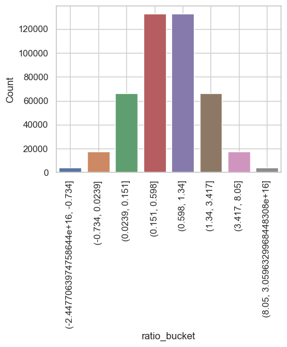

```python
# Plotting the distribution of 'ratio_bucket' using df1
plt.figure(figsize=(5, 6))
sns.countplot(x='ratio_bucket', data=df1)
plt.xticks(rotation=90)
plt.xlabel('ratio_bucket')
plt.ylabel('Count')
plt.grid(True)
plt.tight_layout()

plt.show()
```

### 3.9 Feature 9: Combine Agency name and Cardholder last name

##### One of reasons for combine those two variables is different agencies may have multiple cardholders with various spending habits. Some cardholders may frequently make large purchases, but others may make small ones. By combining agency and cardholder, people can capture individual cardholder behaviors and detect the potential anomalies specific to them. For example, if a cardholder who usually spends 100 to 200 dollars suddenly has a transaction for a few thousand dollars, this might be an anomaly.

```python
# Combine 'Agency_Name' and 'Cardholder_Last_Name' into a single feature
df['agency_cardholder'] = df['Agency_Name'] + '_' + df['Cardholder_Last_Name']
df[['Agency_Name', 'Cardholder_Last_Name', 'agency_cardholder']].head()
```

|  | Agency_Name | Cardholder_Last_Name | agency_cardholder |
| --- | --- | --- | --- |
| 0 | OKLAHOMA STATE UNIVERSITY | Mason | OKLAHOMA STATE UNIVERSITY_Mason |
| 1 | OKLAHOMA STATE UNIVERSITY | Mason | OKLAHOMA STATE UNIVERSITY_Mason |
| 2 | OKLAHOMA STATE UNIVERSITY | Massey | OKLAHOMA STATE UNIVERSITY_Massey |
| 3 | OKLAHOMA STATE UNIVERSITY | Massey | OKLAHOMA STATE UNIVERSITY_Massey |
| 4 | OKLAHOMA STATE UNIVERSITY | Mauro-Herrera | OKLAHOMA STATE UNIVERSITY_Mauro-Herrera |

```python
agg_stats = df.groupby('agency_cardholder')['Amount'].agg('mean').reset_index()
agg_stats.columns = ['agency_cardholder', 'mean_amount']

df = pd.merge(df, agg_stats, on='agency_cardholder', how='left')

percentiles = [0, 0.01, 0.05, 0.2, 0.5, 0.8, 0.95, 0.99, 1]
df['amount_percentile'] = pd.qcut(df['Amount'], q=percentiles)
df
```

|  | Year_Month | Agency_Number | Agency_Name | Cardholder_Last_Name | Cardholder_First_Initial | Description | Amount | Vendor | Transaction_Date | Posted_Date | ... | log_amount | day_of_week | day_of_week_frequency | day_of_week_freq_bucket | amount_zscore | daily_transaction_count | daily_transaction_bucket | agency_cardholder | mean_amount | amount_percentile |
| --- | --- | --- | --- | --- | --- | --- | --- | --- | --- | --- | --- | --- | --- | --- | --- | --- | --- | --- | --- | --- | --- |
| 0 | 2013-07-01 | 1000 | OKLAHOMA STATE UNIVERSITY | Mason | C | GENERAL PURCHASE | 890.00 | NACAS | 2013-07-30 | 2013-07-31 | ... | 6.792344 | Tuesday | 37 | (17.0, 53.0] | 0.088295 | 4 | (2.0, 7.0] | OKLAHOMA STATE UNIVERSITY_Mason | 230.586355 | (441.37, 1487.133] |
| 1 | 2013-07-01 | 1000 | OKLAHOMA STATE UNIVERSITY | Mason | C | ROOM CHARGES | 368.96 | SHERATON HOTEL | 2013-07-30 | 2013-07-31 | ... | 5.913395 | Tuesday | 37 | (17.0, 53.0] | -0.010639 | 4 | (2.0, 7.0] | OKLAHOMA STATE UNIVERSITY_Mason | 230.586355 | (104.89, 441.37] |
| 2 | 2013-07-01 | 1000 | OKLAHOMA STATE UNIVERSITY | Massey | J | GENERAL PURCHASE | 165.82 | SEARS.COM 9300 | 2013-07-29 | 2013-07-31 | ... | 5.116915 | Monday | 49 | (17.0, 53.0] | -0.049211 | 1 | (0.999, 2.0] | OKLAHOMA STATE UNIVERSITY_Massey | 372.164189 | (104.89, 441.37] |
| 3 | 2013-07-01 | 1000 | OKLAHOMA STATE UNIVERSITY | Massey | T | GENERAL PURCHASE | 96.39 | WAL-MART #0137 | 2013-07-30 | 2013-07-31 | ... | 4.578724 | Tuesday | 61 | (53.0, 185.0] | -0.062394 | 2 | (0.999, 2.0] | OKLAHOMA STATE UNIVERSITY_Massey | 372.164189 | (24.99, 104.89] |
| 4 | 2013-07-01 | 1000 | OKLAHOMA STATE UNIVERSITY | Mauro-Herrera | M | HAMMERMILL COPY PLUS COPY EA | 125.96 | STAPLES DIRECT | 2013-07-30 | 2013-07-31 | ... | 4.843872 | Tuesday | 15 | (5.0, 17.0] | -0.056780 | 1 | (0.999, 2.0] | OKLAHOMA STATE UNIVERSITY_Mauro-Herrera | 93.818028 | (104.89, 441.37] |
| ... | ... | ... | ... | ... | ... | ... | ... | ... | ... | ... | ... | ... | ... | ... | ... | ... | ... | ... | ... | ... | ... |
| 442453 | 2014-06-01 | 98000 | GRAND RIVER DAM AUTH. | Cardholder | e | GENERAL PURCHASE | 992.00 | TOTAL VALVE SYSTEMS | 2014-06-20 | 2014-06-23 | ... | 6.900731 | Friday | 390 | (185.0, 979.0] | 0.107663 | 12 | (7.0, 24.0] | GRAND RIVER DAM AUTH._Cardholder | 12515.635762 | (441.37, 1487.133] |
| 442454 | 2014-06-01 | 98000 | GRAND RIVER DAM AUTH. | Cardholder | e | GENERAL PURCHASE | 2415.00 | PRYOR WASTE & RECYCLING L | 2014-06-20 | 2014-06-23 | ... | 7.789869 | Friday | 390 | (185.0, 979.0] | 0.377861 | 12 | (7.0, 24.0] | GRAND RIVER DAM AUTH._Cardholder | 12515.635762 | (1487.133, 4298.568] |
| 442455 | 2014-06-01 | 98000 | GRAND RIVER DAM AUTH. | Cardholder | e | GENERAL PURCHASE | 177.50 | ACCURATE ENVIROMENTAL LAB | 2014-06-20 | 2014-06-23 | ... | 5.184589 | Friday | 390 | (185.0, 979.0] | -0.046993 | 12 | (7.0, 24.0] | GRAND RIVER DAM AUTH._Cardholder | 12515.635762 | (104.89, 441.37] |
| 442456 | 2014-06-01 | 98000 | GRAND RIVER DAM AUTH. | Cardholder | e | GENERAL PURCHASE | 32457.00 | RED BUD SERVICE INC | 2014-06-19 | 2014-06-23 | ... | 10.387702 | Thursday | 400 | (185.0, 979.0] | 6.082209 | 15 | (7.0, 24.0] | GRAND RIVER DAM AUTH._Cardholder | 12515.635762 | (4298.568, 1903858.37] |
| 442457 | 2014-06-01 | 98000 | GRAND RIVER DAM AUTH. | Cardholder | e | GENERAL PURCHASE | 4714.07 | WARRENCAT CREDIT DEPT | 2014-06-20 | 2014-06-23 | ... | 8.458519 | Friday | 390 | (185.0, 979.0] | 0.814406 | 12 | (7.0, 24.0] | GRAND RIVER DAM AUTH._Cardholder | 12515.635762 | (4298.568, 1903858.37] |

442458 rows × 25 columns

##### For qcut method, if a cardholder's tranaction amount is significantly higher or lower than most transactions like in highest 1% or lowest 1%, these transactions can be identified as anomalies.

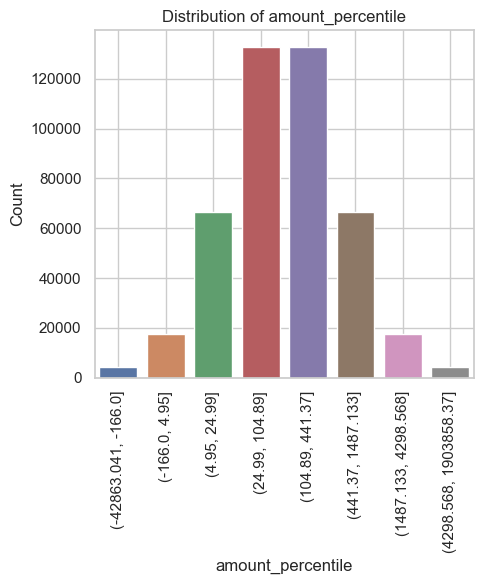

```python
import matplotlib.pyplot as plt
import seaborn as sns

plt.figure(figsize=(5, 6))
sns.countplot(x='amount_percentile', data=df)
plt.xticks(rotation=90)
plt.xlabel('amount_percentile')
plt.ylabel('Count')
plt.title('Distribution of amount_percentile')
plt.grid(True)
plt.tight_layout()
plt.show()
```

### 3.10 Feature 10: Frequency of Agency Cardholder

##### The frequency of transactions for each agency and cardholder combination can highligh normal behavior patterns. For example, if a cardholder from a specific agency generally performs a consistent number of transactions, this count means their usual activity level. If the frequency of transaction for a particular agency_cardholder deviates significantly from the norm, it can indicate potential anomalies. For example, a cardholder who usually performs around 50 transactions monthly suddenly having 200 transactions may indicate the anomalies.

```python
df['agency_cardholder_frequency'] = df.groupby('agency_cardholder')['agency_cardholder'].transform('count')

df[['Agency_Name', 'Cardholder_Last_Name', 'agency_cardholder', 'agency_cardholder_frequency']].head()
```

|  | Agency_Name | Cardholder_Last_Name | agency_cardholder | agency_cardholder_frequency |
| --- | --- | --- | --- | --- |
| 0 | OKLAHOMA STATE UNIVERSITY | Mason | OKLAHOMA STATE UNIVERSITY_Mason | 214 |
| 1 | OKLAHOMA STATE UNIVERSITY | Mason | OKLAHOMA STATE UNIVERSITY_Mason | 214 |
| 2 | OKLAHOMA STATE UNIVERSITY | Massey | OKLAHOMA STATE UNIVERSITY_Massey | 265 |
| 3 | OKLAHOMA STATE UNIVERSITY | Massey | OKLAHOMA STATE UNIVERSITY_Massey | 265 |
| 4 | OKLAHOMA STATE UNIVERSITY | Mauro-Herrera | OKLAHOMA STATE UNIVERSITY_Mauro-Herrera | 71 |

### 3.11 Feature 11: Vendor +amount

##### The feature indicates the relationship between vendor and amount for each month. It calculates the average transaction amount by vendor and month, and compares each individual transaction amount to this average. Extreme high or low transaction amount compared to the vendor's monthly average might indicate outliers which may be potential fraud.

```python
stat_by_vendor = df1.groupby(['Vendor','Month'])['Amount'].mean()
stat_by_vendor = pd.DataFrame(stat_by_vendor).reset_index()
stat_by_vendor.columns = ['Vendor','Month','Vendor_meanamount']
```

```python
#Merge the Average to the original data
df1 = pd.merge(df1, stat_by_vendor, how='left', on=['Vendor','Month'])
```

```python
df1['vendor_month_avg_ratio_amount'] = np.where(df1['Vendor_meanamount'] == 0, 0, df1['Amount'] / df1['Vendor_meanamount'])
```

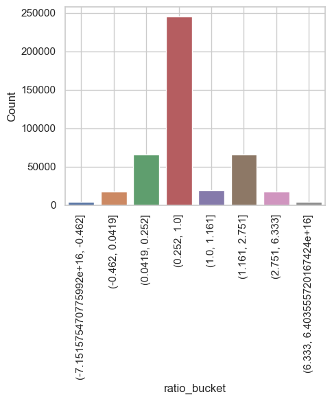

```python
#Using pd.qcut()
percentiles = [0, 0.01, 0.05, 0.2, 0.5, 0.8, 0.95, 0.99, 1]

df1['ratio_bucket'] = pd.qcut(df1['vendor_month_avg_ratio_amount'], q=percentiles)
df1[['Vendor', 'Month', 'Amount', 'vendor_month_avg_ratio_amount', 'ratio_bucket']].head()

plt.figure(figsize=(5, 6))
sns.countplot(x='ratio_bucket', data=df1)
plt.xticks(rotation=90)
plt.xlabel('ratio_bucket')
plt.ylabel('Count')
plt.grid(True)
plt.tight_layout()

plt.show()
```

### 3.12 Feature 12: Time Difference between Transaction and Posted Date

##### This feature indicates the time delay between the transaction date and the posted date. Longer or shorter delays might indicate anomalies. Unusual delays in posting transaction might refer to anomalies or inefficiencies in processing.

```python
df['Transaction_Date'] = pd.to_datetime(df['Transaction_Date'])
df['Posted_Date'] = pd.to_datetime(df['Posted_Date'])

df['time_difference'] = (df['Posted_Date'] - df['Transaction_Date']).dt.days
df['time_difference']
```

```
0         1
1         1
2         2
3         1
4         1
         ..
442453    3
442454    3
442455    3
442456    4
442457    3
Name: time_difference, Length: 442458, dtype: int64
```

```python
percentiles = [0, 0.01, 0.05, 0.2, 0.5, 0.8, 0.95, 0.99, 1]
df['time_diff_bucket'] = pd.qcut(df['time_difference'], q=percentiles, duplicates='drop')

df[['time_difference', 'time_diff_bucket']].head()
```

|  | time_difference | time_diff_bucket |
| --- | --- | --- |
| 0 | 1 | (-0.001, 1.0] |
| 1 | 1 | (-0.001, 1.0] |
| 2 | 2 | (1.0, 2.0] |
| 3 | 1 | (-0.001, 1.0] |
| 4 | 1 | (-0.001, 1.0] |

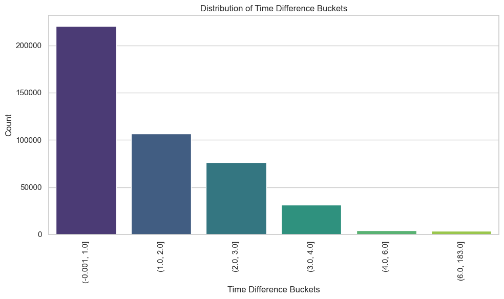

```python
# Plot the distribution of time_diff_bucket
plt.figure(figsize=(10, 6))
sns.countplot(x='time_diff_bucket', data=df, palette='viridis')
plt.xticks(rotation=90)
plt.xlabel('Time Difference Buckets')
plt.ylabel('Count')
plt.title('Distribution of Time Difference Buckets')
plt.tight_layout()
plt.show()
```

### 3.13 Feature 13: Transaction Day of the Week

##### This feature extracts the day of the week from the Transaction_Date. Certain agencies or cardholders have regular spending behavior based on certain day of the week, for example, more transactions on weekdays than on weekends. The large transactions on days when transactions are rarely made might indicate anomalies. For example, an agency that rarely conducts transactions on Sundays suddenly has a large volume of transactions. That might be the fraud.

```python
df['transaction_day_of_week'] = df['Transaction_Date'].dt.dayofweek
df['day_of_week_bucket'] = pd.qcut(df['transaction_day_of_week'], q=percentiles, duplicates='drop')
df[['transaction_day_of_week', 'day_of_week_bucket']].head()
```

|  | transaction_day_of_week | day_of_week_bucket |
| --- | --- | --- |
| 0 | 1 | (-0.001, 1.0] |
| 1 | 1 | (-0.001, 1.0] |
| 2 | 0 | (-0.001, 1.0] |
| 3 | 1 | (-0.001, 1.0] |
| 4 | 1 | (-0.001, 1.0] |

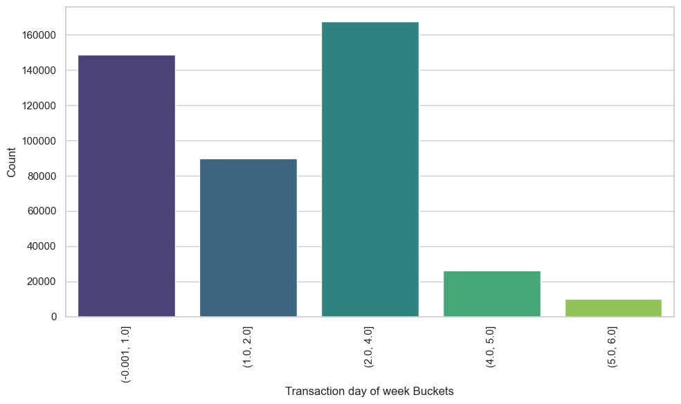

```python
# Plot the distribution of time_diff_bucket
plt.figure(figsize=(10, 6))
sns.countplot(x='day_of_week_bucket', data=df, palette='viridis')
plt.xticks(rotation=90)
plt.xlabel('Transaction day of week Buckets')
plt.ylabel('Count')
plt.tight_layout()
plt.show()
```

### 3.14 Feature 14: Vendor Frequency

##### This feature calculates how frequently a particular vendor appears for each cardholder. Some vendors may appear regularly, while others might be used rarely. Unusual transactions with rarely used vendors might be anomalies. Using qcut() cut vendor_frequency variable into serveral percentiles, less number of count for the distribution plot might be anomalies.

```python
#Frequency of each vendor for each cardholder
df['vendor_frequency'] = df.groupby(['Cardholder_Last_Name', 'Vendor'])['Vendor'].transform('count')
df['vendor_frequency_bucket'] = pd.qcut(df['vendor_frequency'], q=percentiles, duplicates='drop')
df[['vendor_frequency', 'vendor_frequency_bucket']].head()
```

|  | vendor_frequency | vendor_frequency_bucket |
| --- | --- | --- |
| 0 | 2 | (0.999, 6.0] |
| 1 | 4 | (0.999, 6.0] |
| 2 | 2 | (0.999, 6.0] |
| 3 | 8 | (6.0, 32.0] |
| 4 | 4 | (0.999, 6.0] |

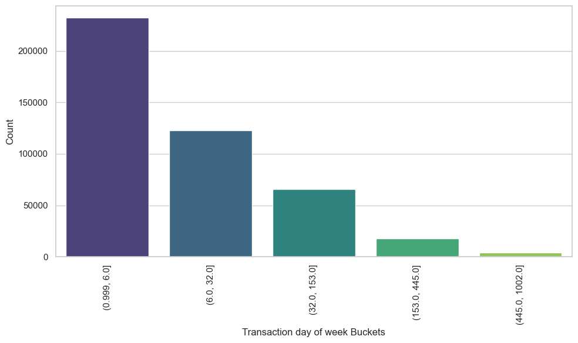

```python
# Plot the distribution of time_diff_bucket
plt.figure(figsize=(10, 6))
sns.countplot(x='vendor_frequency_bucket', data=df, palette='viridis')
plt.xticks(rotation=90)
plt.xlabel('Transaction day of week Buckets')
plt.ylabel('Count')
plt.tight_layout()
plt.show()
```

### 3.15 Feature 15: One-Hot Encoding for Merchant Category

##### One-Hot encoding for merchant category helps making text into number, which helps following modeling process

```python
# One-hot encode 'Merchant_Category'
df = pd.get_dummies(df, columns=['Merchant_Category'], prefix='MCC', drop_first=True)
```

### Merge existing columns including one-hot Encoding!

```python
# Get the column names for each dataframe
df1_columns = df1.columns
df2_columns = df2.columns
df_columns = df.columns
common_columns_12 = df1_columns.intersection(df2_columns)
common_columns_123 = common_columns_12.intersection(df_columns)
merged_df = pd.merge(df1, df2, how='outer', on=list(common_columns_12))
merged_df = pd.merge(merged_df, df, how='outer', on=list(common_columns_123))
```

```python
merged_df
```

|  | Year_Month | Agency_Number | Agency_Name | Cardholder_Last_Name | Cardholder_First_Initial | Description | Amount | Vendor | Transaction_Date | Posted_Date | ... | MCC_WELDING SERVICES | MCC_WESTIN HOTELS | MCC_WESTJET AIRLINES | MCC_WHOLESALE CLUBS | MCC_WIG AND TOUPEE SHOPS | MCC_WOMEN'S ACCESSORY AND SPECIALTY STORES | MCC_WOMEN'S READY-TO-WEAR STORES | MCC_WRECKING AND SALVAGE YARDS | MCC_WYNDHAM HOTELS | MCC_WYNN LAS VEGAS |
| --- | --- | --- | --- | --- | --- | --- | --- | --- | --- | --- | --- | --- | --- | --- | --- | --- | --- | --- | --- | --- | --- |
| 0 | 2013-07-01 | 1000 | OKLAHOMA STATE UNIVERSITY | Mason | C | GENERAL PURCHASE | 890.00 | NACAS | 2013-07-30 | 2013-07-31 | ... | 0 | 0 | 0 | 0 | 0 | 0 | 0 | 0 | 0 | 0 |
| 1 | 2013-07-01 | 1000 | OKLAHOMA STATE UNIVERSITY | Mason | C | GENERAL PURCHASE | 890.00 | NACAS | 2013-07-30 | 2013-07-31 | ... | 0 | 0 | 0 | 0 | 0 | 0 | 0 | 0 | 0 | 0 |
| 2 | 2013-07-01 | 1000 | OKLAHOMA STATE UNIVERSITY | Mason | C | GENERAL PURCHASE | 890.00 | NACAS | 2013-07-30 | 2013-07-31 | ... | 0 | 0 | 0 | 0 | 0 | 0 | 0 | 0 | 0 | 0 |
| 3 | 2013-07-01 | 1000 | OKLAHOMA STATE UNIVERSITY | Mason | C | GENERAL PURCHASE | 890.00 | NACAS | 2013-07-30 | 2013-07-31 | ... | 0 | 0 | 0 | 0 | 0 | 0 | 0 | 0 | 0 | 0 |
| 4 | 2013-07-01 | 1000 | OKLAHOMA STATE UNIVERSITY | Mason | C | GENERAL PURCHASE | 890.00 | NACAS | 2013-07-30 | 2013-07-31 | ... | 0 | 0 | 0 | 0 | 0 | 0 | 0 | 0 | 0 | 0 |
| ... | ... | ... | ... | ... | ... | ... | ... | ... | ... | ... | ... | ... | ... | ... | ... | ... | ... | ... | ... | ... | ... |
| 1055895 | 2014-06-01 | 98000 | GRAND RIVER DAM AUTH. | Cardholder | e | GENERAL PURCHASE | 177.50 | ACCURATE ENVIROMENTAL LAB | 2014-06-20 | 2014-06-23 | ... | 0 | 0 | 0 | 0 | 0 | 0 | 0 | 0 | 0 | 0 |
| 1055896 | 2014-06-01 | 98000 | GRAND RIVER DAM AUTH. | Cardholder | e | GENERAL PURCHASE | 32457.00 | RED BUD SERVICE INC | 2014-06-19 | 2014-06-23 | ... | 0 | 0 | 0 | 0 | 0 | 0 | 0 | 0 | 0 | 0 |
| 1055897 | 2014-06-01 | 98000 | GRAND RIVER DAM AUTH. | Cardholder | e | GENERAL PURCHASE | 32457.00 | RED BUD SERVICE INC | 2014-06-19 | 2014-06-23 | ... | 0 | 0 | 0 | 0 | 0 | 0 | 0 | 0 | 0 | 0 |
| 1055898 | 2014-06-01 | 98000 | GRAND RIVER DAM AUTH. | Cardholder | e | GENERAL PURCHASE | 4714.07 | WARRENCAT CREDIT DEPT | 2014-06-20 | 2014-06-23 | ... | 0 | 0 | 0 | 0 | 0 | 0 | 0 | 0 | 0 | 0 |
| 1055899 | 2014-06-01 | 98000 | GRAND RIVER DAM AUTH. | Cardholder | e | GENERAL PURCHASE | 4714.07 | WARRENCAT CREDIT DEPT | 2014-06-20 | 2014-06-23 | ... | 0 | 0 | 0 | 0 | 0 | 0 | 0 | 0 | 0 | 0 |

1055900 rows × 477 columns